# ミュラーリヤー実験

>>>練習する（角度2条件の上昇・下降系列1回ずつ、計4回です）

>>>実験を実施する（角度5条件 x 上昇・下降 x 2回反復で20回です）

教示修正版（長い方を選ぶ）。

>>>練習する（角度2条件の上昇・下降系列1回ずつ、計4回です）

>>>実験を実施する（角度5条件 x 上昇・下降 x 2回反復で20回です）

## 背景

- 錯視とは・・・
  - 知覚と物理的な性質の乖離。
  - さまざまな幾何学錯視がある。
- ミューラリヤー錯視の紹介
  - 先の両端の矢羽によって長さが変わる。
  - 内向きの場合は短く、外向きの場合は長く見える。
- 実験の目的
  - ミュラーリヤー錯視における矢羽の角度の効果を追試。

## 方法

- 標準刺激（矢羽付き横棒）と比較刺激（横棒）の長さを比較して、比較刺激が標準刺激に比べて長いか短いかを判断する、という実験です。
- 標準刺激は左側、比較刺激は右側に出でてきます。

### 手続き

1要因の被験者内計画です。

- 矢羽の角度 (5水準)
  - 60, 120, 180, 240, 300°
  - それぞれの条件に対して、上昇系列と下降系列を2回ずつ繰り替えします。
  - 全部で20系列の閾値測定を行います。

### 測定法

- 極限法（上下法・2択）
  - 上昇系列：比較刺激は最初は短く、だんだん長くなります。「長い」反応が出現したら系列終了です。
  - 下降系列：比較刺激は最初は長く、だんだん短くなります。「短い」反応が出現したら系列終了です。

## 分析

### サンプルデータ

- sampleData.xlsx を置いておきます。
- 内容は以下のとおりです。

|  | rt | sequence_index | response_index | std_angle | up_down | comp_len | response |
| --- | --- | --- | --- | --- | --- | --- | --- |
| 1 | 1388.17000002018 | 0 | 0 | 300 | down | 230 | long |
| 2 | 45.1449999818578 | 0 | 1 | 300 | down | 220 | long |
| 3 | 294.510000006994 | 0 | 2 | 300 | down | 210 | long |
| 4 | 891.12000001478 | 0 | 3 | 300 | down | 200 | long |
| 5 | 1256.56999999773 | 0 | 4 | 300 | down | 190 | long |
| 6 | 454.595000017434 | 0 | 5 | 300 | down | 180 | short |
| 7 | 748.145000019576 | 1 | 0 | 60 | up | 100 | short |
| 8 | 182.399999990593 | 1 | 1 | 60 | up | 110 | short |
| 9 | 281.92000000854 | 1 | 2 | 60 | up | 120 | short |
| 10 | 1862.67999999108 | 1 | 3 | 60 | up | 130 | short |

[output cut: 155 more lines]

### 分析方法

- 見てわかるとおり、上昇系列では”long”、下降系列では”short”の反応が出たら系列終了です。
- 各系列のPSEは、各系列の最後の長さと、最後から2番目の長さの平均を取ればいいです。
- 各系列のPSEを算出したあとに、条件ごとのPSEの平均を計算します。
  - これが、各被験者の代表値なので、これを提出してもらうのが良さそうです。
- この計算を行うRのコードを載せておきます。
  - 結果をエクセルに貼り付けて、`sampleData.xlsx`というファイル名（これは任意）で保存してあるとします。

```r
library(readxl) # エクセルファイルの読み込みに使う。
dt = read_excel("sampleData.xlsx") # 読み込む
head(dt) # データの構造を確認しましょう。
```

```
## # A tibble: 6 × 7
##       rt sequence_index response_index std_angle up_down comp_len response
##    <dbl>          <dbl>          <dbl>     <dbl> <chr>      <dbl> <chr>
## 1 1388.               0              0       300 down         230 long
## 2   45.1              0              1       300 down         220 long
## 3  295.               0              2       300 down         210 long
## 4  891.               0              3       300 down         200 long
## 5 1257.               0              4       300 down         190 long
## 6  455.               0              5       300 down         180 short
```

```r
str(dt) # データの構造を確認しましょう。
```

```
## tibble [165 × 7] (S3: tbl_df/tbl/data.frame)
##  $ rt            : num [1:165] 1388.2 45.1 294.5 891.1 1256.6 ...
##  $ sequence_index: num [1:165] 0 0 0 0 0 0 1 1 1 1 ...
##  $ response_index: num [1:165] 0 1 2 3 4 5 0 1 2 3 ...
##  $ std_angle     : num [1:165] 300 300 300 300 300 300 60 60 60 60 ...
##  $ up_down       : chr [1:165] "down" "down" "down" "down" ...
##  $ comp_len      : num [1:165] 230 220 210 200 190 180 100 110 120 130 ...
##  $ response      : chr [1:165] "long" "long" "long" "long" ...
```

```r
summary(dt) # データの要約に変なところがないか確認しましょう。
```

```
##        rt          sequence_index  response_index     std_angle
##  Min.   :  45.15   Min.   : 0.00   Min.   : 0.000   Min.   : 60.0
##  1st Qu.: 211.60   1st Qu.: 5.00   1st Qu.: 2.000   1st Qu.:120.0
##  Median : 454.75   Median :11.00   Median : 4.000   Median :180.0
##  Mean   : 581.47   Mean   :10.13   Mean   : 3.897   Mean   :181.1
##  3rd Qu.: 807.63   3rd Qu.:15.00   3rd Qu.: 6.000   3rd Qu.:240.0
##  Max.   :2663.86   Max.   :19.00   Max.   :11.000   Max.   :300.0
##    up_down             comp_len     response
##  Length:165         Min.   :100   Length:165
##  Class :character   1st Qu.:130   Class :character
##  Mode  :character   Median :160   Mode  :character
##                     Mean   :164
##                     3rd Qu.:190
##                     Max.   :230
```

```r
# 各系列のPSEを抽出します。

# ホントは1行で書けますが、あえてtidyverseは使わずbase functionで行きます。
PSE = c()
for (si in unique(dt$sequence_index)) {
  tmp = subset(dt, sequence_index == si)
  pse = mean(tail(tmp, 2)$comp_len) # 最後の2行のcomp_lenの平均
  PSE = rbind(PSE, data.frame(std_angle = tmp$std_angle[1], pse = pse))
}

knitr::kable(PSE) # データの構造を確認しましょう
```

| std_angle | pse |
| --- | --- |
| 300 | 185 |
| 60 | 135 |
| 120 | 145 |
| 240 | 175 |
| 240 | 175 |
| 300 | 175 |
| 120 | 145 |
| 240 | 175 |
| 180 | 145 |
| 120 | 135 |
| 60 | 135 |
| 60 | 145 |
| 180 | 145 |
| 60 | 125 |
| 300 | 185 |
| 300 | 195 |
| 120 | 145 |
| 180 | 155 |
| 240 | 155 |
| 180 | 155 |

```r
# 各条件ごとの平均値を計算します。
result = aggregate(pse ~ std_angle, data = PSE, FUN = mean)
knitr::kable(result)
```

| std_angle | pse |
| --- | --- |
| 60 | 135.0 |
| 120 | 142.5 |
| 180 | 150.0 |
| 240 | 170.0 |
| 300 | 185.0 |

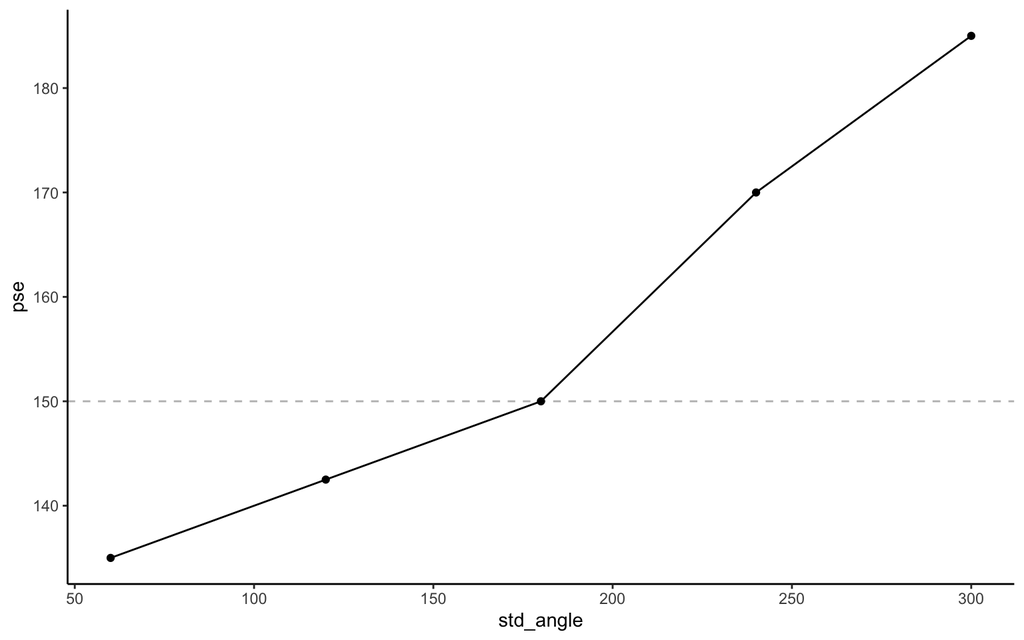

```r
# 図示
library(ggplot2)
ggplot(result, aes(std_angle, pse)) +
  geom_hline(yintercept = 150, colour = "gray", linetype = "dashed")+
  geom_point() + geom_line() +
  theme_classic()
```

以上が、各被験者の集計です。

- 実際の授業では、`result`の中身（条件ごとのPSEの平均）を提出してもらって、複数の人のデータを使ってHADで1要因Repeated Measures ANOVAで解析するのが一般的だと思います。

## 考察のポイント

# さまざまな閾値測定

内向（60°）と外向（300°）の２条件について、さまざまな閾値測定法での実験です。

1. 最初に教示画面が出てきます。
2. スペースキーを押すと、実験が始まります。
3. 実験終了後、データファイル（csvファイル）が自動的にダウンロードされます。ダウンロードされない場合は、同じ内容が画面に表示されるので、その内容をコピペして保存してください。

### 全実験に共通のパラメータ

- 背景領域
  - 色：グレイ
  - 大きさ：600 x 600 px
- 標準刺激（左側）：矢羽あり
  - 矢羽の角度：内向（60°）と外向（300°）
  - 主線（横線）の長さ：150 px
  - 矢羽の長さ：50 px
  - 中心の横位置：背景領域中心から左に150 px
  - 中心の縦位置：背景領域上部から100 px
  - 色：黒
  - 線の太さ：3 px
- 比較刺激（右側）：矢羽なし
  - 中心の横位置：背景領域中心から右に150 px
  - 中心の縦位置：背景領域上部から200 px
  - 色：黒
  - 線の太さ：3 px

## 恒常法

比較刺激（右側）がランダムな長さで提示されます。 比較刺激が標準刺激より長いか短いか判断します。

- 比較刺激の方が長い：右矢印キー
- 比較刺激の方が短い：左矢印キー

読み替えると「左右の刺激のうち長い方を選んで左右矢印キーで回答する」ということです。こちらの方が反応のための認知的負荷が低いように思います。

### パラメータなど

- 比較刺激の長さ：14段階（90 px から 220 px まで10 px刻み）。
- 繰り返し：各条件10回（総試行数：2 x 14 x 10 = 280）
- ITI（反応から次の刺激が出るまで）：100 ms
- 反応するまで刺激を提示。
- データファイル名：`ML-constant.csv`

### データ

1試行＝1行形式で、281行（1行目はタイトル行） x 4列のcsvファイルです。

- rt: 反応時間
- response: 反応（左右矢印のいずれか）
- std_angle: 60なら内向図形、300なら外向図形
- comp_len: 比較刺激の長さ

>>>恒常法実験を実施する

## 恒常法（角度4条件）

- 上の恒常法と同じですが、角度条件の水準が増えています（60, 120, 240, 300）。
- 2x2の2要因計画となります。
- 向き
  - 内向（60, 120）
  - 外向（240, 300）
- 主線との角度の大きさ
  - 小（60, 300 = 60°）
  - 大（120, 240 = 120°）

>>>恒常法実験（角度4条件）を実施する

## 極限法

比較刺激（右側）の長さが徐々に変化します。 標準刺激と比較刺激の長さが同じになったと思ったらスペースキーを押します。 長い→短いに変化する下降系列と短い→長いに変化する上昇系列があります。

### パラメータなど

- 比較刺激の変化量：10 px
- 比較刺激の変化のタイミング：2秒ごとに、上昇系列なら長く、下降系列なら短くなります。
- 比較刺激の初期値：50 px (上昇系列）/ 250 px（下降系列）
- 繰り返し：上昇系列、下降系列それぞれ4回（総試行数：2 x 2 x 4 = 16）
- ITI（反応から次の刺激が出るまで）：250 ms
- データファイル名：`ML-limit.csv`

### データ

1試行＝1行形式で、17行（1行目はタイトル行） x 4列のcsvファイルです。

- rt: 反応時間
- std_angle: 60なら内向図形、300なら外向図形
- up_down: 上昇系列か下降系列か
- comp_len: 反応時の比較刺激の長さ（=PSE）

>>>極限法実験を実施する

## 調整法

比較刺激（右側）の長さが標準刺激の長さと同じくらいに見えるように、上下矢印キーで比較刺激の長さを変化させて、スペースキーで回答します。 最初に長めの刺激がでる場合と、最初に短めの刺激が出る場合があります。

### パラメータなど

- 比較刺激の変化量：10 px
- 比較刺激の初期値：半分の試行は50 px、残り半分は250 px（順番はランダム）
- 繰り返し：外向図形、内向図形それぞれ10試行（総試行数：2 x 10 = 20）
- ITI（反応から次の刺激が出るまで）：250 ms
- データファイル名：`ML-adjustment.csv`

### データ

1試行＝1行形式で、21行（1行目はタイトル行） x 4列のcsvファイルです。

- rt: 反応時間
- std_angle: 60なら内向図形、300なら外向図形
- up_down: 上昇系列か下降系列か
- comp_len: 反応時の比較刺激の長さ（=PSE）

>>>調整法実験を実施する

## 調整法（角度5条件）

- 上の調整法と同じですが、角度条件の水準が増えています（60, 120, 180, 240, 300）。

>>>調整法実験（角度5条件）を実施する

## マグニチュード推定法

比較刺激と標準刺激を見比べて、比較刺激（右側）を100とした時の標準刺激の長さを回答します。上下矢印キーで数字を調整して、スペースキーで回答します。

### パラメータなど

- 繰り返し：外向図形、内向図形それぞれ1試行（総試行数：2）
- データファイル名：`ML-magest.csv`

### データ

1試行＝1行形式で、3行（1行目はタイトル行） x 3列のcsvファイルです。

- rt: 反応時間
- std_angle: 60なら内向図形、300なら外向図形
- comp_len_resp: 回答した数字

>>>マグニチュード推定法実験を実施する